# Advanced data visualization with R and ggplot2

a practical by [Yan Holtz](https://github.com/holtzy) - 10 April 2019

> This practical follows the previous basic [introduction to ggplot2](https://www.yan-holtz.com/teaching). It allows to go further with `ggplot2`: annotation, theme customization, color palette, output formats, scales, and more.

# Get ready

The following libraries are needed all along the practical. Install them with `install.packages()` if you do not have them already. Then load them with `library()`.

```r
# Load it
library(ggplot2)
library(dplyr)
library(hrbrthemes)
library(viridis)
library(plotly)
```

# 1- General appearance

## → Titles

Q1.1 The code below builds a basic histogram for Rbnb apartment prices on the French Riviera. It shows only value under 300 euros. Add code to:

- add a title with `ggtitle()`
- change axis labels `xlab()` and `ylab()`
- change axis limits with `xlim()` and `ylim()`

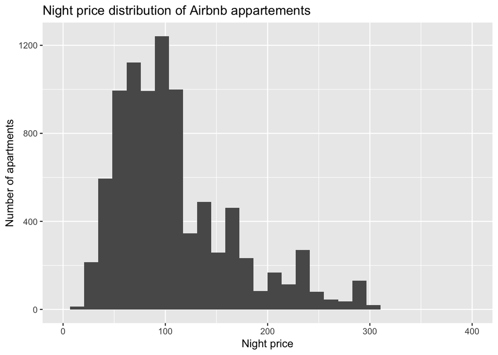

```r
# Libraries
library(ggplot2)

# Load dataset from github
data <- read.table("https://raw.githubusercontent.com/holtzy/data_to_viz/master/Example_dataset/1_OneNum.csv", header=TRUE)

# Make the histogram
data %>%
  filter( price<300 ) %>%
  ggplot( aes(x=price)) +
    geom_histogram() +
    ggtitle("Night price distribution of Airbnb appartements") +
    xlab("Night price") +
    ylab("Number of apartments") +
    xlim(0,400)
```

## → Chart components

All `ggplot2` chart components can be changed using the `theme()` function. You can see a complete list of components in the official [documentation](https://ggplot2.tidyverse.org/reference/theme.html).

Note: components are changed using different functions: `element_text()`, `element_line()` for lines and so on..

Q1.2 Reproduce the previous histogram and change:

- plot title size and color with `plot.title`
- X axis title size and color with `axis.title.x`
- Grid appearance with `panel.grid.major`

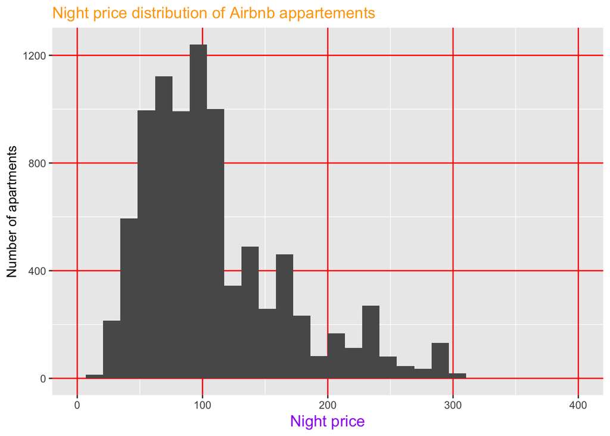

```r
# Make the histogram
data %>%
  filter( price<300 ) %>%
  ggplot( aes(x=price)) +
    geom_histogram() +
    ggtitle("Night price distribution of Airbnb appartements") +
    xlab("Night price") +
    ylab("Number of apartments") +
    xlim(0,400) +
    theme(
      plot.title = element_text(size=13, color="orange"),
      axis.title.x = element_text(size=13, color="purple"),
      panel.grid.major = element_line(colour = "red")
    )
```

## → Themes

Q1.3 `ggplot2` offers a set of pre-built themes. Try the followings to see which one you like the most:

- `theme_bw()`
- `theme_dark()`
- `theme_minimal()`
- `theme_classic()`

See a complete list [here](https://www.r-graph-gallery.com/192-ggplot-themes/).

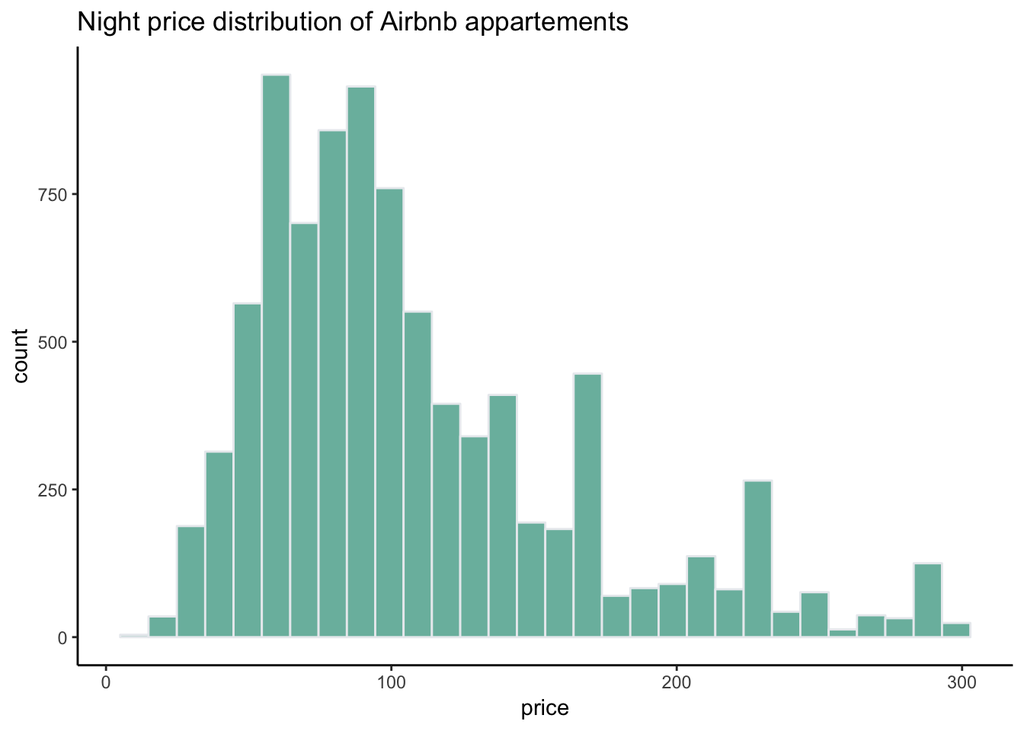

```r
# Load dataset from github
data <- read.table("https://raw.githubusercontent.com/holtzy/data_to_viz/master/Example_dataset/1_OneNum.csv", header=TRUE)

# Make the histogram
data %>%
  filter( price<300 ) %>%
  ggplot( aes(x=price)) +
    geom_histogram(fill="#69b3a2", color="#e9ecef", alpha=0.9) +
    ggtitle("Night price distribution of Airbnb appartements") +
    theme_classic()
```

Q1.4 The `hrbrthemes` package provides my favourite style. Install the package, load it, and apply the `theme_ipsum()`. Documentation is [here](https://github.com/hrbrmstr/hrbrthemes).

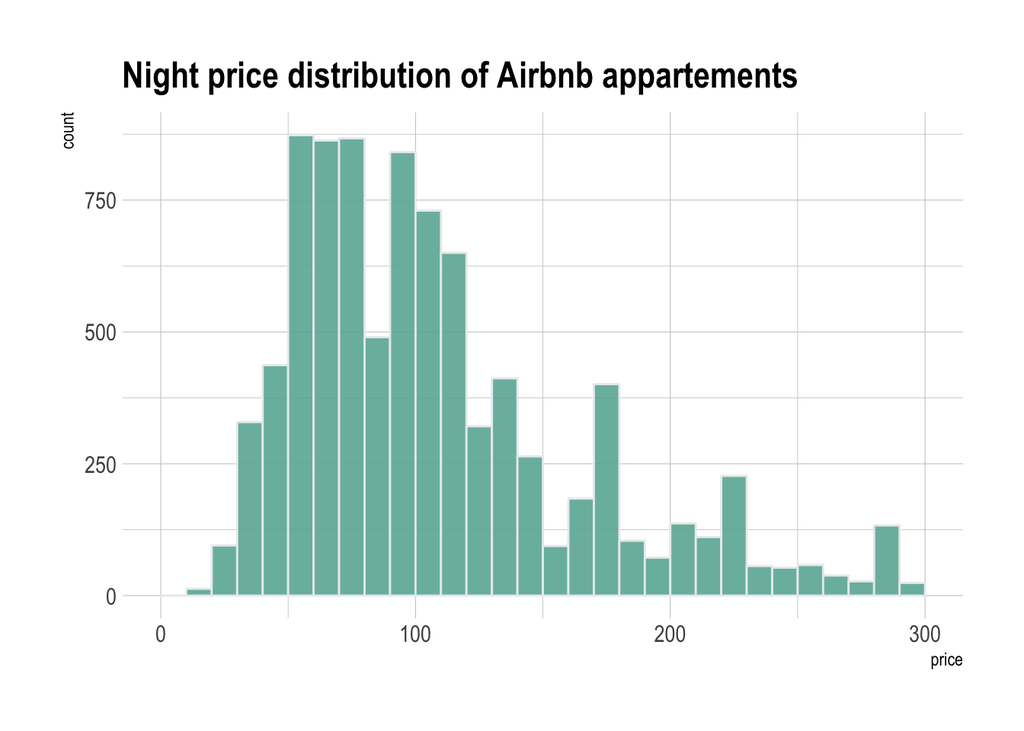

```r
# Libraries
library(tidyverse)
library(hrbrthemes)
library(viridis)

# Load dataset from github
data <- read.table("https://raw.githubusercontent.com/holtzy/data_to_viz/master/Example_dataset/1_OneNum.csv", header=TRUE)

# Make the histogram
data %>%
  filter( price<300 ) %>%
  ggplot( aes(x=price)) +
    stat_bin(breaks=seq(0,300,10), fill="#69b3a2", color="#e9ecef", alpha=0.9) +
    ggtitle("Night price distribution of Airbnb appartements") +
    theme_ipsum()
```

# 2- Annotation

Annotation is a crucial component of a good dataviz. It can turn a boring graphic into an interesting and insightful way to convey information. Dataviz is often separated in two main types: exploratory and explanatory analysis. Annotation is used for the second type.

## → Text

The most common type of annotation is text. Let’s say you have a spike in a line plot. It totally makes sense to highlight it, and explain more in details what it is about.

Q1.1 Build a line plot showing the bitcoin price evolution between 2013 and 2018. Dataset is located here and can be read directly with `read.table()`. What part of the chart would you highlight?

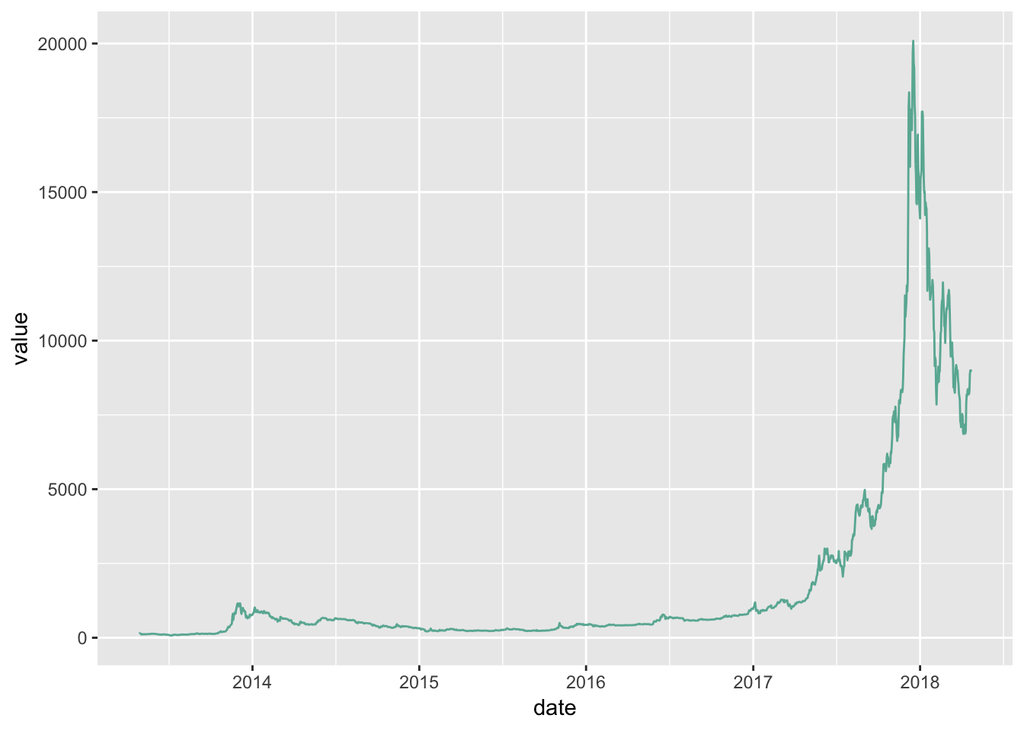

```r
# Load dataset from github
data <- read.table("https://raw.githubusercontent.com/holtzy/data_to_viz/master/Example_dataset/3_TwoNumOrdered.csv", header=T)
data$date <- as.Date(data$date)

# plot
data %>%
  ggplot( aes(x=date, y=value)) +
    geom_line(color="#69b3a2")
```

Q1.2 Use the `annotate()` function to add text. Annotate requires several arguments:

- `geom`: type of annotation, use `text`
- `x`: position on the X axis
- `y`: position on the Y axis
- `label`: what you want to write
- Optional: `color`, `size`, `angle` and [more](https://www.r-graph-gallery.com/233-add-annotations-on-ggplot2-chart/).

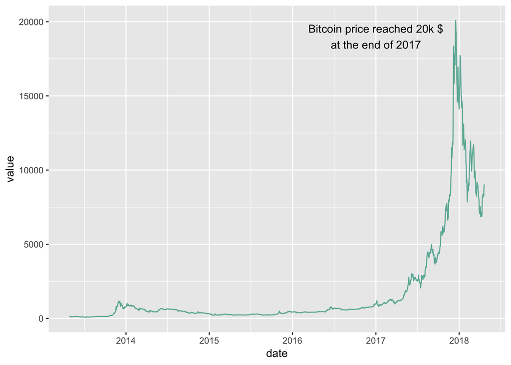

```r
# plot
data %>%
  ggplot( aes(x=date, y=value)) +
    geom_line(color="#69b3a2") +
    annotate(geom="text", x=as.Date("2017-01-01"), y=19000,
             label="Bitcoin price reached 20k $\nat the end of 2017")
```

## → Shape

Q1.3 Find the exact spike `date` and its `value`. Use this information to add a circle around the spike. This is done with the `annotate()` function once more:

- `geom`: use `point`
- `x`: position on the X axis
- `y`: position on the Y axis
- `shape`: use 21, to be able to change the `fill` and the `color` arguments. (fill=inside, color=stroke)
- `size`

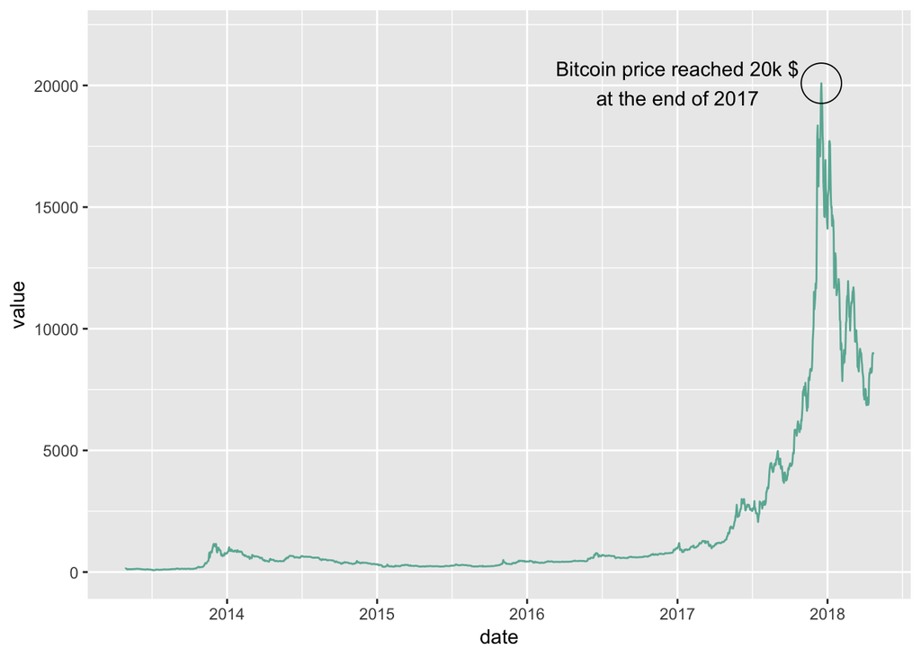

```r
# Find spike date and value:
# data %>% arrange(desc(value)) %>% head(1)

# plot
data %>%
  ggplot( aes(x=date, y=value)) +
    geom_line(color="#69b3a2") +
    ylim(0,22000) +
    annotate(geom="text", x=as.Date("2017-01-01"), y=20089,
             label="Bitcoin price reached 20k $\nat the end of 2017") +
    annotate(geom="point", x=as.Date("2017-12-17"), y=20089, size=10, shape=21, fill="transparent")
```

## → Abline

Q1.4 Add a horizontal abline to show what part of the curve is over 5000 $. This is possible thanks to the `geom_hline()` function that requires its `yintercept` argument.

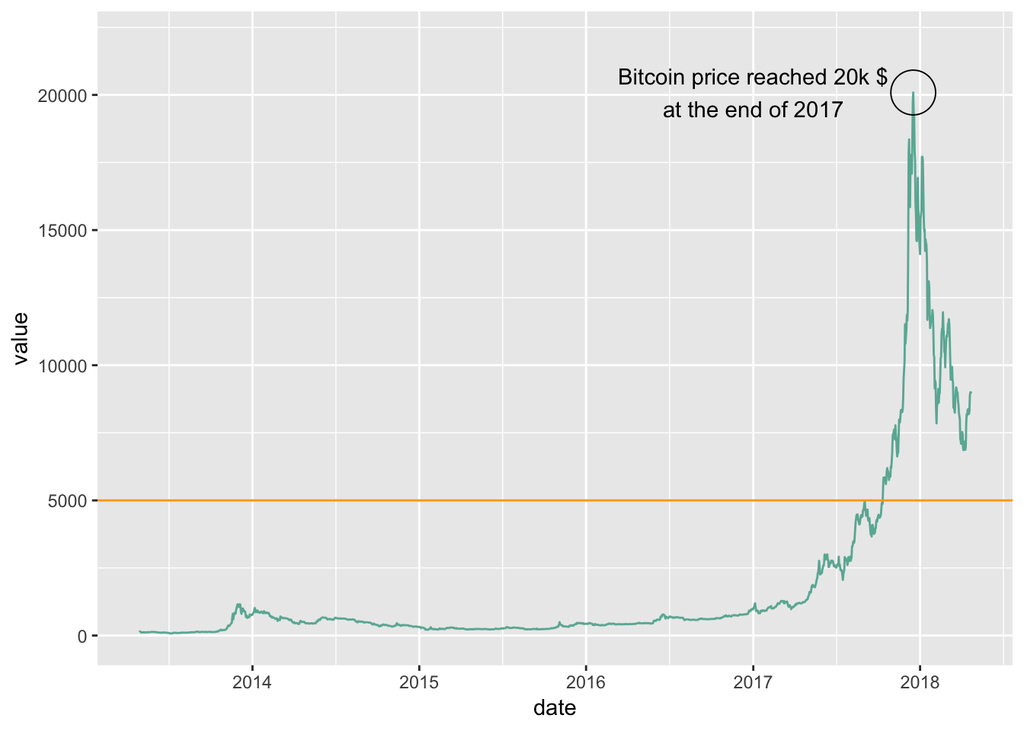

```r
# Find spike date and value:
# data %>% arrange(desc(value)) %>% head(1)

# plot
data %>%
  ggplot( aes(x=date, y=value)) +
    geom_line(color="#69b3a2") +
    ylim(0,22000) +
    annotate(geom="text", x=as.Date("2017-01-01"), y=20089,
             label="Bitcoin price reached 20k $\nat the end of 2017") +
    annotate(geom="point", x=as.Date("2017-12-17"), y=20089, size=10, shape=21, fill="transparent") +
    geom_hline(yintercept=5000, color="orange", size=.5)
```

## → Color

Q1.5 Build a scatterplot based on the `gapminder` dataset. Use `gdpPercap` for the X axis, `lifeExp` for the Y axis, and `pop` for bubble size. Keep only the year 2007.

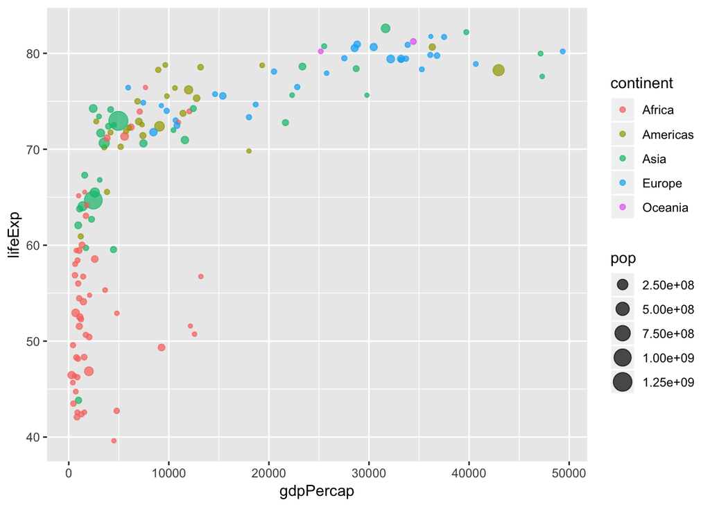

```r
# Data are available in the gapminder package
library(gapminder)
data <- gapminder %>% filter(year=="2007") %>% select(-year)

# Basic scatterplot
ggplot( data, aes(x=gdpPercap, y=lifeExp, size = pop, color = continent)) +
    geom_point(alpha=0.7)
```

Q1.6 Highlight South Africa in the chart: draw it in red, with all other circles in grey. Follow those steps:

- create a new column with `mutate`: this new column has the value `yes` if `country=="South Africa"`, `no` otherwise. This is possible thanks to the `ifelse` function.
- in the aesthetics part of the ggplot call, use this new column to control dot colors
- use `scale_color_manual()` to control the color of both group. Use a bright color for the country to highlight, and grey for the others.

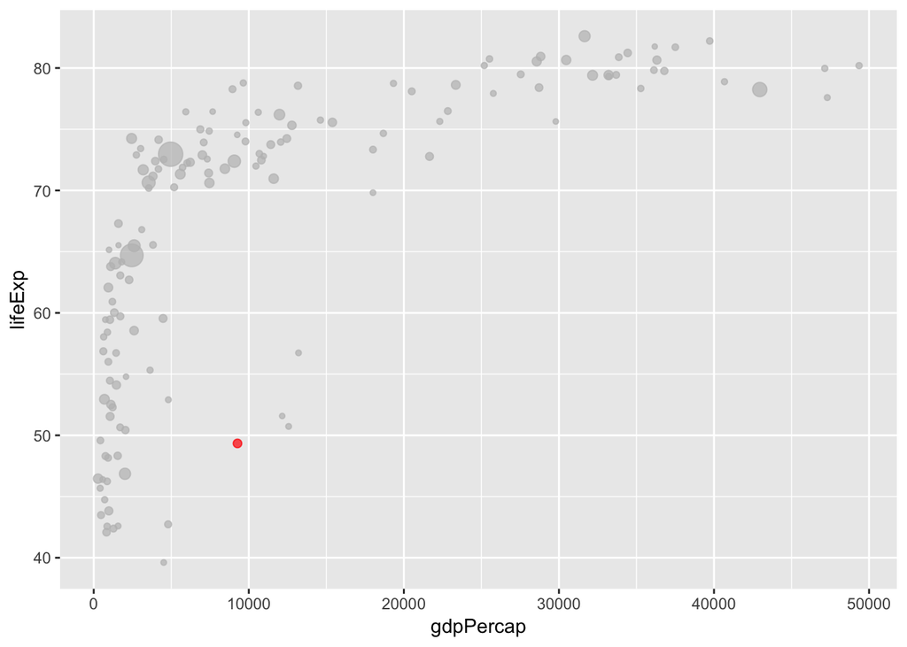

```r
# Basic scatterplot
data %>%
  mutate(isSouthAfrica = ifelse(country=="South Africa", "yes", "no")) %>%
  ggplot( aes(x=gdpPercap, y=lifeExp, size = pop, color = isSouthAfrica)) +
    geom_point(alpha=0.7) +
    scale_color_manual(values=c("grey", "red")) +
    theme(legend.position="none")
```

## → Multiple text

Q1.7 Highlight every country with `gdpPercap > 5000` & `lifeExp < 60` in red. Write their names using the `geom_text_repel of the`ggrepel` package to avoid text overlapping.

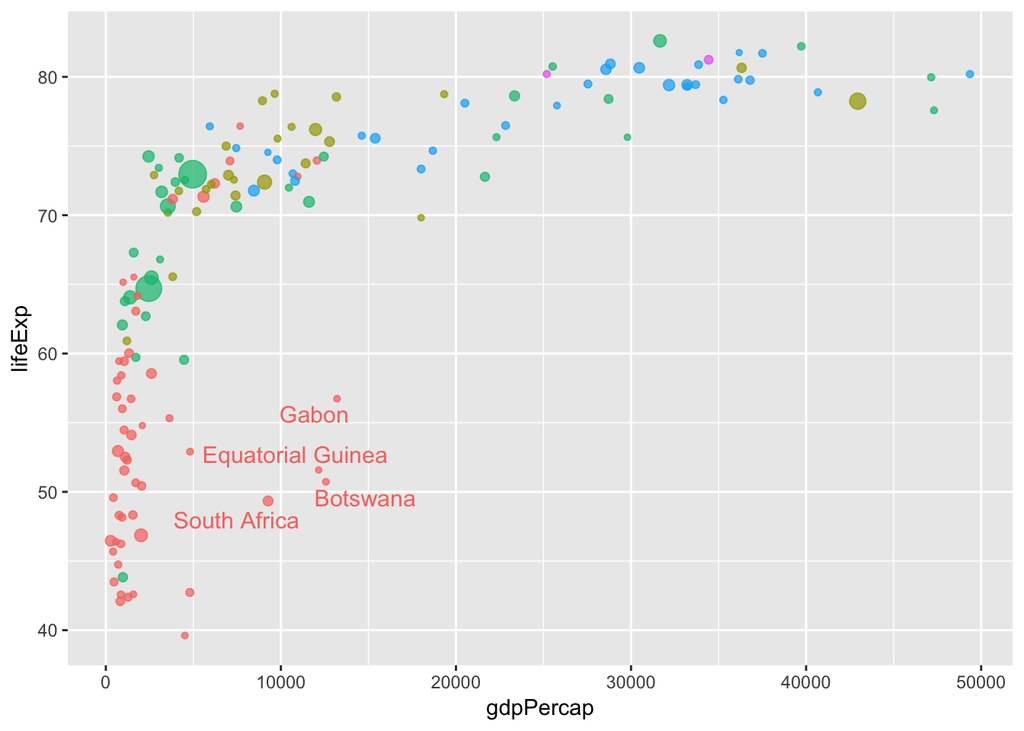

```r
# ggrepel
library(ggrepel)

# prepare data
tmp <- data %>%
  mutate( annotation = ifelse(gdpPercap > 5000 & lifeExp < 60, "yes", "no"))

# plot
tmp %>%
  ggplot( aes(x=gdpPercap, y=lifeExp, size = pop, color = continent)) +
    geom_point(alpha=0.7) +
    theme(legend.position="none") +
    geom_text_repel(data=tmp %>% filter(annotation=="yes"), aes(label=country), size=4 )
```

# 3- Faceting

Faceting is a very powerful data visualization technique. It splits the figure in small subsets, usually one by level of a categorical variable. `ggplot2` offers 2 functions to build small multiples: `facet_wrap()` and `facet_grid()`.

## → facet_wrap()

Q3.1 Build a [spaghetti chart](https://www.data-to-viz.com/caveat/spaghetti.html) showing the evolution of 9 baby names in the US. (See code [here](https://www.data-to-viz.com/caveat/spaghetti.html)). What’s wrong with this chart?

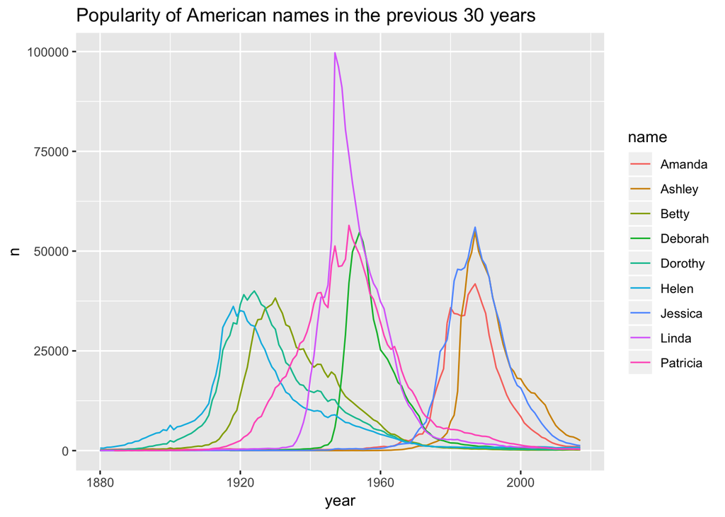

```r
# Libraries
library(babynames)

# Load dataset from github
data <- babynames %>%
  filter(name %in% c("Ashley", "Amanda", "Jessica",    "Patricia", "Linda", "Deborah",   "Dorothy", "Betty", "Helen")) %>%
  filter(sex=="F")

# line plot = spaghetti chart
data %>%
  ggplot( aes(x=year, y=n, group=name, color=name)) +
    geom_line() +
    ggtitle("Popularity of American names in the previous 30 years")
```

Q3.2 Use the `facet_wrap()` function to build one area chart for each name. Basically, you have to provide a categorical variable to the function. It will build a chart for each of its level.

Have a look to the Y axis. What do you observe? Is it a good option?

You should get something like this:

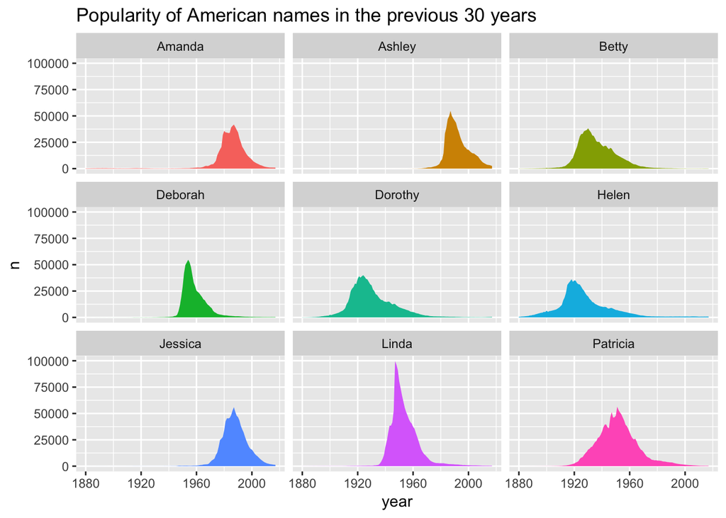

```r
data %>%
  ggplot( aes(x=year, y=n, group=name, fill=name)) +
    geom_area() +
    ggtitle("Popularity of American names in the previous 30 years") +
    theme(
      legend.position="none",
    ) +
    facet_wrap(~name)
```

Q3.3 Find out how to use the `scale` option to have different Y axis limits for each subset. Does it make sense? In which conditions?

You should get something like this:

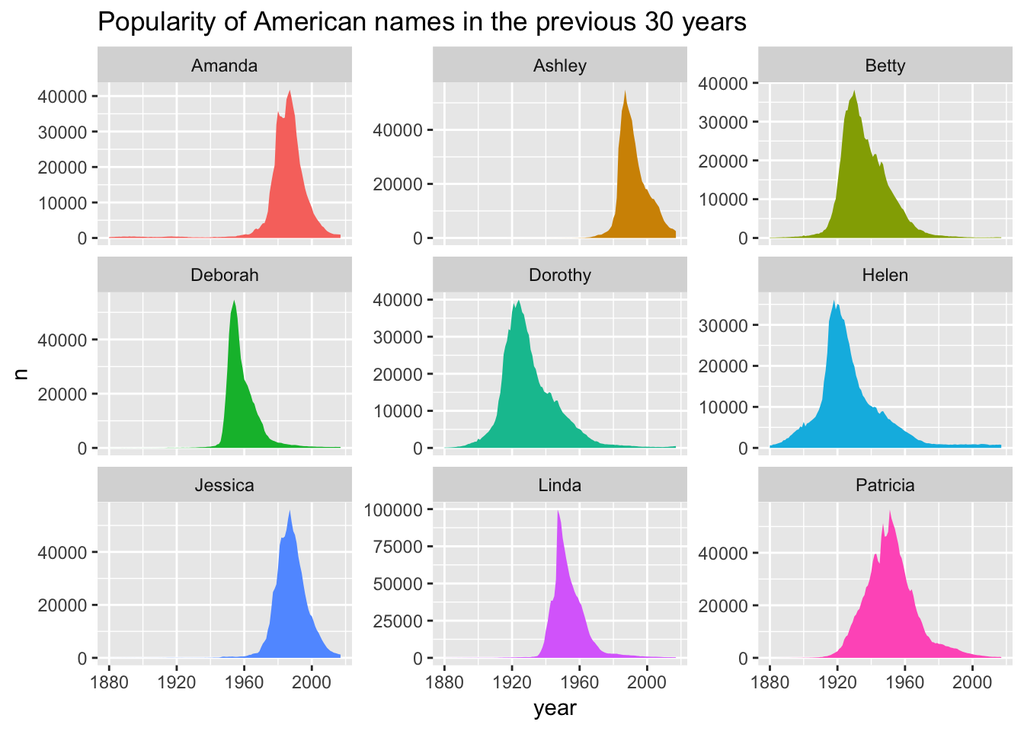

```r
data %>%
  ggplot( aes(x=year, y=n, group=name, fill=name)) +
    geom_area() +
    ggtitle("Popularity of American names in the previous 30 years") +
    theme(
      legend.position="none",
    ) +
    facet_wrap(~name, scale="free_y")
```

## → facet_grid()

Bonus Find out what the `facet_grid()` function does. Why is it different to `facet_wrap()`?

You should get something like:

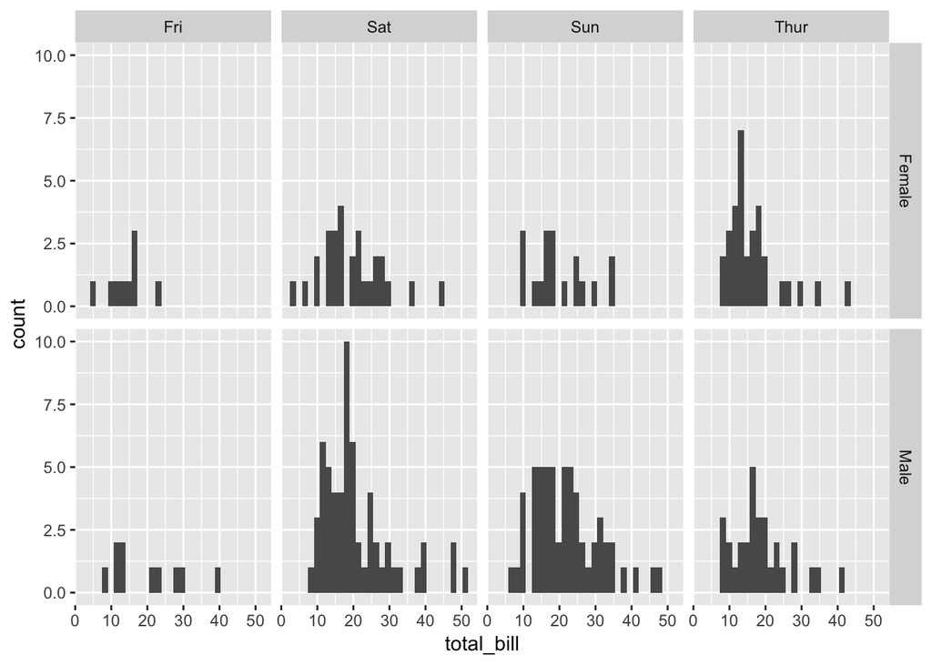

```r
# Load dataset from github
data <- read.table("https://raw.githubusercontent.com/holtzy/data_to_viz/master/Example_dataset/10_OneNumSevCatSubgroupsSevObs.csv", header=T, sep=",")

# Plot
ggplot(data, aes(x=total_bill)) +
  geom_histogram() +
  facet_grid(sex~day)
```

# 4- Saving plots

Q4.1 - Save the previous chart as a `PNG` file using the `ggsave()` function. Where is saved the file?

```r
# save the plot in an object called p
p <- ggplot(data, aes(x=total_bill)) +
  geom_histogram() +
  facet_grid(sex~day)

# Save the plot
ggsave(p, filename = "chartFromRPractical.png")
```

Q4.2 - Specify the complete path before file name to save the chart at a specific location.

# 5- Colors

Picking the right colors is a crucial step for a good dataviz. R offers awesome options and packages to make the right choices. Here is an overview of the main options.

## → One color

Q5.1 Several options exist to pick one color. Change the histogram color using the `fill` argument on the chart below using each of the following options:

- plain color name. Type `colors()` to see all the options.
- using `rgb()`. This function provides the quantity of red, green and blue to build the color. Plus an argument for the opacity. Example, try `rgb(.7, .6, .3, .2)`
- using `HTML` colors. Use [this website](https://www.w3schools.com/colors/colors_picker.asp) to pick one you like.

[figure not shown]

```r
# Load dataset from github
data <- read.table("https://raw.githubusercontent.com/holtzy/data_to_viz/master/Example_dataset/1_OneNum.csv", header=TRUE)

# Make the histogram
data %>%
  filter( price<300 ) %>%
  ggplot( aes(x=price)) +
    geom_histogram(fill="steelblue") +
    ggtitle("Night price distribution of Airbnb appartements") +
    theme_ipsum()
```

## → Discrete color palette

Q5.2 Build a scatterplot based on the `iris` dataset. Use `Sepal.Length` for the X axis, `Petal.Length` for the Y axis. Use `color=Species` to color groups.

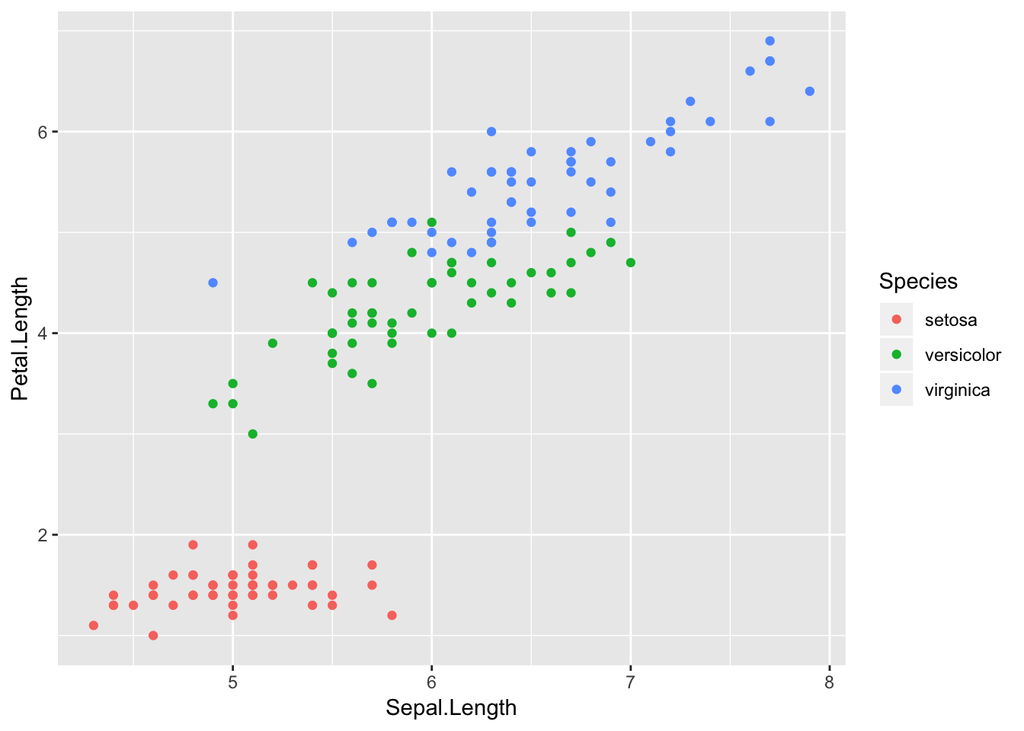

```r
ggplot(iris, aes(x=Sepal.Length, y=Petal.Length, color=Species)) +
  geom_point()
```

Q5.3 It is possible to set the color scale manually using `scale_color_manual()`. Use the hint below to see how to use it and apply it to the previous scatterplot.

Note: it is a bad practice to pick colors randomly. Your palette will be ugly and will probably not be colorblind friendly.

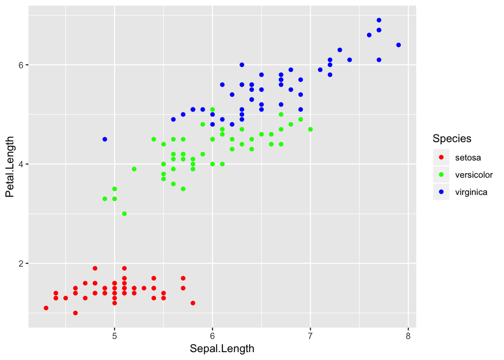

```r
ggplot(iris, aes(x=Sepal.Length, y=Petal.Length, color=Species)) +
  geom_point() +
  scale_color_manual( values=c("red","green","blue"))
```

Q5.4 Fortunately, people already tackeled this issue for us and created packages offering nice color palettes. The most famous one is `RColorBrewer`. Palettes are already available in `ggplot2`. See all of them [here](https://www.r-graph-gallery.com/38-rcolorbrewers-palettes/), and use one on your chart using `scale_color_brewer()`.

Pick the one you like the most and apply it to to previous scatterplot. Use it to color the `Species`.

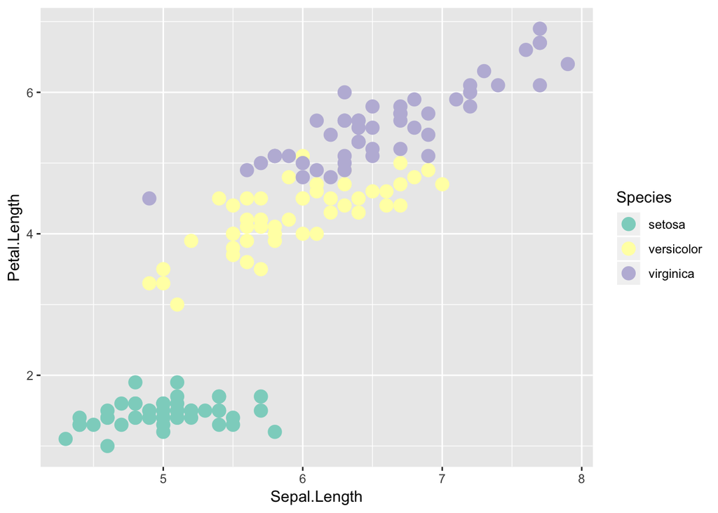

```r
ggplot(iris, aes(x=Sepal.Length, y=Petal.Length, color=Species)) +
  geom_point(size=4) +
  scale_color_brewer(palette = "Set3")
```

## → Continuous color palette

Q5.5 `RColorBrewer` also offers continuous color palette. However they must be called through the `scale_color_distiller` function. Use the palette you like the most to color circles depending on `Sepal_length`.

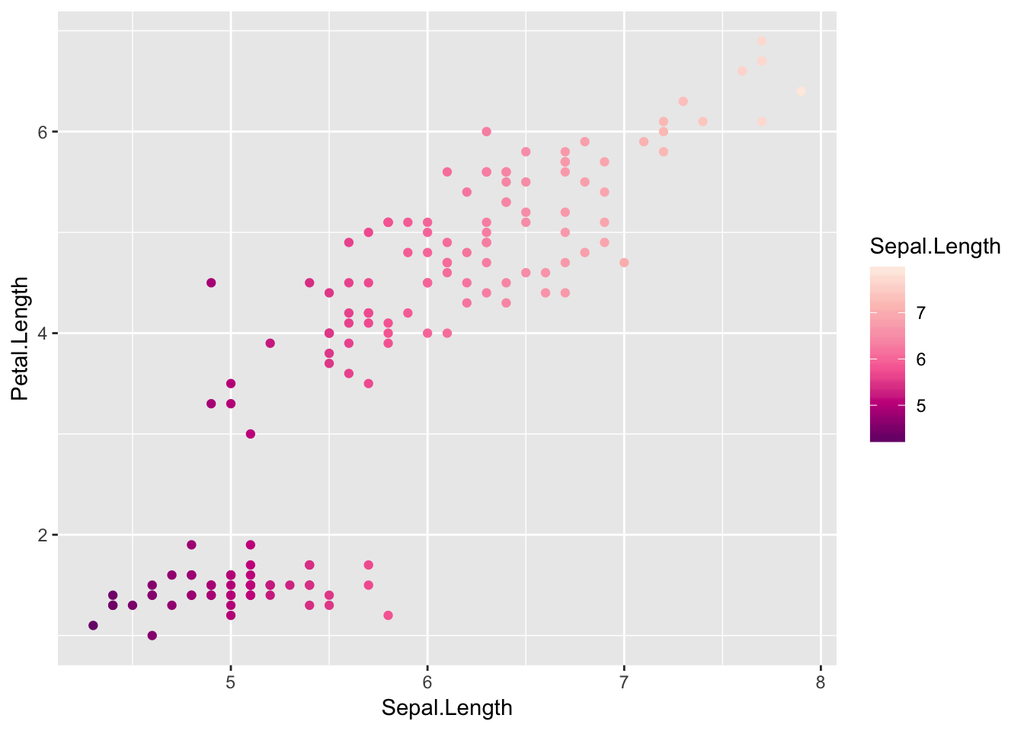

```r
ggplot(iris, aes(x=Sepal.Length, y=Petal.Length, color=Sepal.Length)) +
  geom_point() +
  scale_color_distiller(palette = "RdPu")
```

# 6- Interactive charts

An interactive chart is a chart on which you can zoom, hover shapes to get tooltips, click to trigger actions and more. Building interactive charts requires javascript under the hood, but it is relatively easy to build it using R packages that wrap the javascript for you. This type of packages are called [HTML widgets](https://www.htmlwidgets.org).

## → Plotly

Q6.1 Build the `gapminder` bubble plot you’ve already done in the annotation part of this practical. Store it in an object called `p`

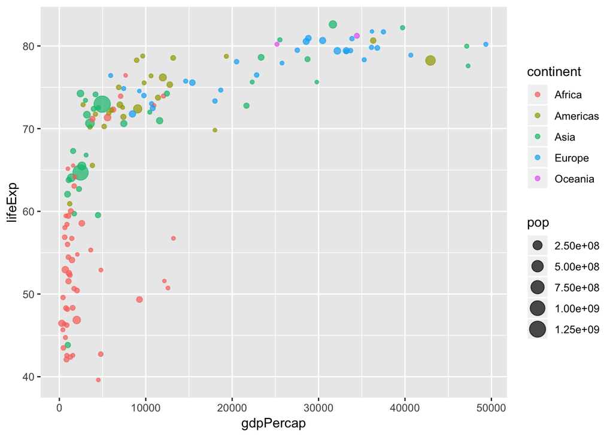

```r
# load data
library(gapminder)
data <- gapminder %>% filter(year=="2007") %>% select(-year)

# Basic ggplot
p <- data %>%
  ggplot( aes(x=gdpPercap, y=lifeExp, size = pop, color = continent)) +
    geom_point(alpha=0.7)
p
```

Q6.2 Install and load the `plotly` package. Build an interactive chart using the `ggplotly()` function. What are the new functionalities of this chart? Is it useful? What could be better?

```r
# Interactive version
library(plotly)
ggplotly(p)
```

[interactive chart not shown]

Q6.3 Let’s improve the tooltip of the chart:

- build a new column called `myText`. Fill it with whatever you want to show in the tooltip.
- add a new aesthetics: `text=myText`
- in the `ggplotly()` call, add `tooltip="text"`

```r
# Basic ggplot
p <- data %>%
  mutate(myText=paste("This country is: " , country )) %>%
  ggplot( aes(x=gdpPercap, y=lifeExp, size = pop, color = continent, text=myText)) +
    geom_point(alpha=0.7)

ggplotly(p, tooltip="text")
```

[interactive chart not shown]

## → Leaflet

Q6.4 Use the HTML widget called `leaflet` to build an interactive map showing the earthquakes described in the dataset called `quakes`. Code is fully provided here, since cartography with R could deserve an entire practical. The idea is just to discover to potential offered in a few lines of code:

```r
# Library
library(leaflet)

# load example data (Fiji Earthquakes) + keep only 100 first lines
data(quakes)
quakes =  head(quakes, 100)

# Create a color palette with handmade bins.
mybins=seq(4, 6.5, by=0.5)
mypalette = colorBin( palette="YlOrBr", domain=quakes$mag, na.color="transparent", bins=mybins)

# Final Map
leaflet(quakes) %>%
  addTiles()  %>%
  setView( lat=-27, lng=170 , zoom=4) %>%
  addProviderTiles("Esri.WorldImagery") %>%
  addCircleMarkers(~long, ~lat,
    fillColor = ~mypalette(mag), fillOpacity = 0.7, color="white", radius=8, stroke=FALSE
  ) %>%
  addLegend( pal=mypalette, values=~mag, opacity=0.9, title = "Magnitude", position = "bottomright" )
```

[interactive chart not shown]

## → Heatmap

The `d3heatmap` package allows to build interactive heatmaps in a few line of code. Let’s see how it works

Q6.5 Load [this](http://datasets.flowingdata.com/ppg2008.csv) dataset in R. Have a look to the first rows. Describe it. ([source](https://flowingdata.com/2010/01/21/how-to-make-a-heatmap-a-quick-and-easy-solution/))

```r
# Load data
data <- read.csv("http://datasets.flowingdata.com/ppg2008.csv", row.names = 1)

# head(data)
# summary(data)
```

Q6.6 R offers a `heatmap()` function to build… heatmaps! Apply it to the dataset. What do you observe? Are you happy with this heatmap? What’s wrong with it? How can we solve the issue?

Note: input dataset must be at the `matrix` format to be accepted by the function. Use `as.matrix()` to get this format.

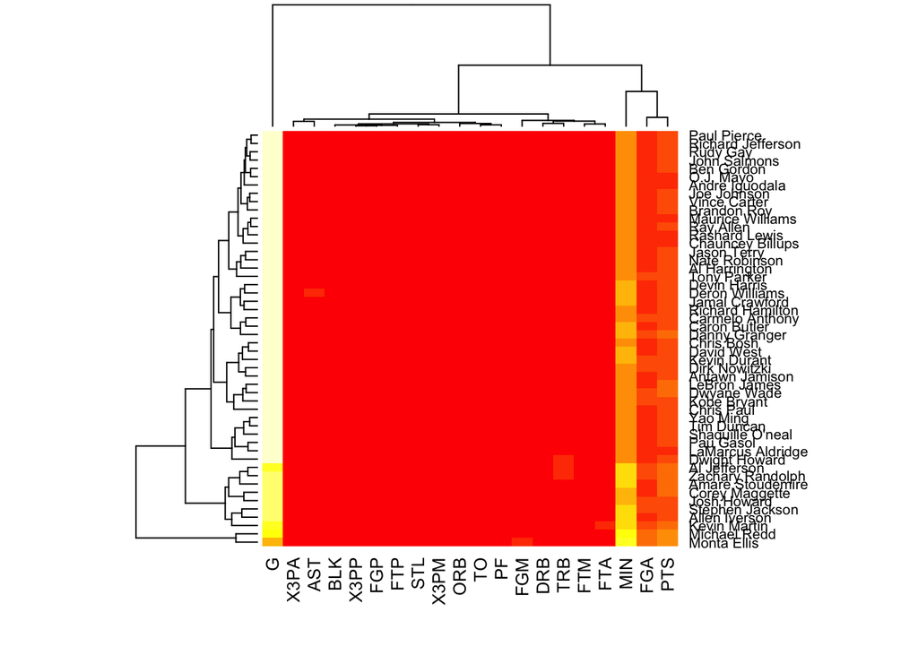

```r
# Make the heatmap
heatmap( as.matrix(data) )
```

Q6.7 Check the `scale` option of the `heatmap()` function. What is it for? Can it help us? How? Use it to improve the heatmap.

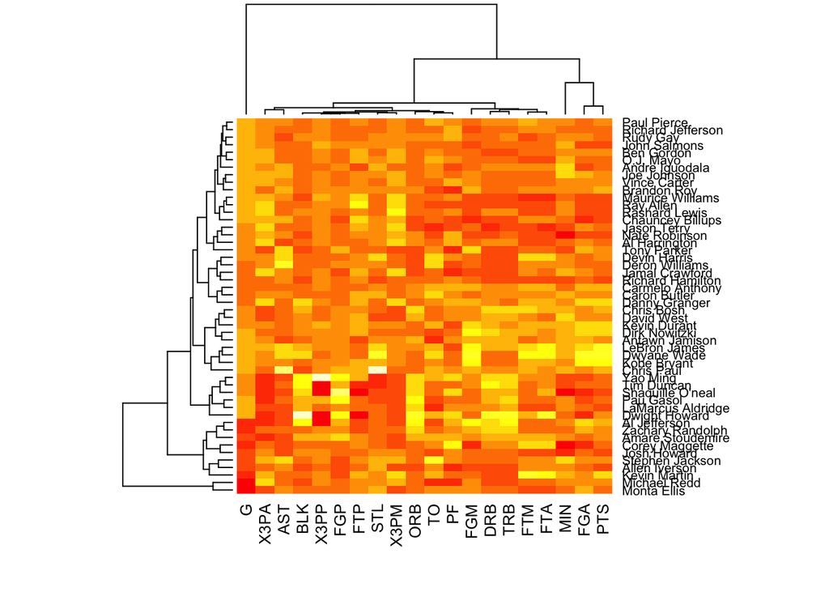

```r
# Make the heatmap
heatmap( as.matrix(data), scale = "column")
```

Q6.8 `d3heatmap()` uses exactly the same syntax than `heatmap()`. Use the function to get an interactive version of the previous heatmap!

```r
# Load library
library(d3heatmap)

# Build heatmap
d3heatmap(data, scale = "column")
```

[interactive chart not shown]

## → Time Seriesx

Q6.9 - Use the HTML widget called `dygraphs` to build an interactive line plot of the [bitcoin price evolution](https://raw.githubusercontent.com/holtzy/data_to_viz/master/Example_dataset/3_TwoNumOrdered.csv). Try to reproduce the example below.

```r
# Library
library(dygraphs)
library(xts)          # To make the convertion data-frame / xts format

# Load dataset from github
data <- read.table("https://raw.githubusercontent.com/holtzy/data_to_viz/master/Example_dataset/3_TwoNumOrdered.csv", header=T)
data$date <- as.Date(data$date)

# Then you can create the xts format, and thus use dygraph
don <- xts(x = data$value, order.by = data$date)

# Use the dygraph HTML widget
dygraph(don) %>%
  dyOptions(labelsUTC = TRUE, fillGraph=TRUE, fillAlpha=0.1, drawGrid = FALSE, colors="#D8AE5A") %>%
  dyRangeSelector() %>%
  dyCrosshair(direction = "vertical") %>%
  dyHighlight(highlightCircleSize = 5, highlightSeriesBackgroundAlpha = 0.2, hideOnMouseOut = FALSE)  %>%
  dyRoller(rollPeriod = 1)
```

[interactive chart not shown]

## → HTML widgets

BONUS - The packages showcased above are just a sample of the possibilities offered by the html widgets. Visit [this website](https://www.htmlwidgets.org/showcase_leaflet.html) to have an overview of what kind of interactive chart you can do with `R`. Pick your favorite example and try to reproduce it.

# 7- Scales

Scales control the details of how data values are translated to visual properties. [Many different scales](https://ggplot2.tidyverse.org/reference/index.html#section-scales) are offered by ggplot2. The most widely one is probably the log scale.

Q7.1 Build a histogram showing the night price distribution of the french riviera apartements ([data here](https://raw.githubusercontent.com/holtzy/data_to_viz/master/Example_dataset/1_OneNum.csv)). Keep all the data, with extreme values.

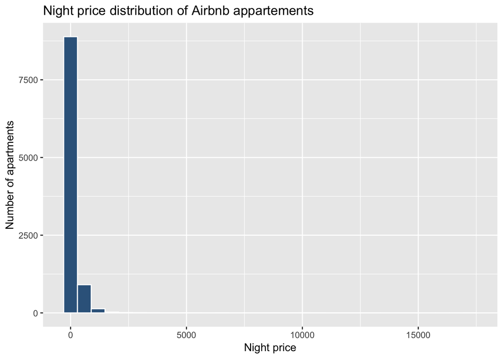

```r
# Libraries
library(ggplot2)

# Load dataset from github
data <- read.table("https://raw.githubusercontent.com/holtzy/data_to_viz/master/Example_dataset/1_OneNum.csv", header=TRUE)

# Make the histogram
data %>%
  ggplot( aes(x=price)) +
    geom_histogram(color="white", fill="steelblue4") +
    ggtitle("Night price distribution of Airbnb appartements") +
    xlab("Night price") +
    ylab("Number of apartments")
```

Q7.2 A common practice to avoid the effect of extreme values is to filter data, or use `xlim` to zoom on a part of the axis. Another approach is to use `scale_x_log10()` to apply a log transformation. Apply this function to the histogram.

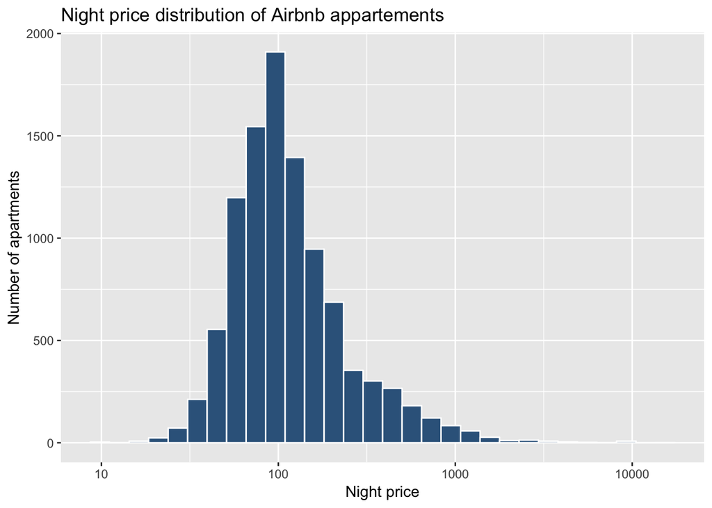

```r
# Libraries
library(ggplot2)

# Load dataset from github
data <- read.table("https://raw.githubusercontent.com/holtzy/data_to_viz/master/Example_dataset/1_OneNum.csv", header=TRUE)

# Make the histogram
data %>%
  ggplot( aes(x=price)) +
    geom_histogram(color="white", fill="steelblue4") +
    ggtitle("Night price distribution of Airbnb appartements") +
    xlab("Night price") +
    ylab("Number of apartments") +
    scale_x_log10()
```

Q7.3 What’s the difference between `scale_x_log10()` and applying the `log()` function on the dataset before doing the chart? Why is it better?

A work by [a practical by [Yan Holtz](https://github.com/holtzy)](https://github.com/holtzy)

*yan.holtz.data@gmail.com*